# Project 2021

### I label encoded all the columns, applied one hot encoding and created dummy variables for categorical features. Also, I visualized some of the categorical variables. The next step would be the modeling, evaluating of fairness and more visualization.

```python
# importing neccessary libraries
import pandas as pd
import numpy as np
import matplotlib.pyplot as plt
from sklearn import preprocessing
from sklearn.preprocessing import LabelEncoder
from sklearn.preprocessing import OneHotEncoder
import seaborn as sns
%pylab inline
%matplotlib inline
```

```python
# reading the data
dm = pd.read_csv('credit.csv')
```

```python
#handy codes
#print(dm.columns)
#dm.dtypes
#dm.set_value(1,'checking_status',2)
#dm.head()
#print(dm.info())
#labelencoder = LabelEncoder()
#dm['checking_status_new'] = labelencoder.fit_transform(dm['checking_status'])
#dataframe.column.dtype
#dataframe.dtypes
```

```python
# labelencoding of checking status column
dm.copy()
for i in range(len(dm['checking_status'])):
    if dm['checking_status'][i] == 'no checking':
        dm['checking_status'][i] = '0'
    elif dm['checking_status'][i] == '<0':
        dm['checking_status'][i] ='1'
    elif dm['checking_status'][i] == '0<=X<200':
        dm['checking_status'][i] = '2'
    elif dm['checking_status'][i] == '>=200':
        dm['checking_status'][i] ='3'
le = preprocessing.LabelEncoder()
dm['checking_status'] = le.fit_transform(dm['checking_status'])
```

```python
#create dummy variables of other parties column
dm ['other_parties'].unique()
dm = pd.concat([dm,pd.get_dummies(dm['other_parties'],dtype='int', prefix='parties')],axis=1)
dm.drop(['other_parties'],axis=1, inplace=True)
```

```python
#create dummy variables  parties column
dm ['credit_history'].unique()
dm = pd.concat([dm,pd.get_dummies(dm['credit_history'],dtype='int', prefix='credit_h')],axis=1)
dm.drop(['credit_history'],axis=1, inplace=True)
```

```python
#create dummy varaibles other purpose column
dm ['purpose'].unique()
dm = pd.concat([dm,pd.get_dummies(dm['purpose'],dtype='int', prefix='purpose')],axis=1)
dm.drop(['purpose'],axis=1, inplace=True)
```

```python
# labelencoding of savings status column
dm.copy()
dm ['savings_status'].unique()
for j in range(len(dm['savings_status'])):
    if dm['savings_status'][j] == 'no known savings':
        dm['savings_status'][j] = '0'
    elif dm['savings_status'][j] == '<100':
        dm['savings_status'][j] ='1'
    elif dm['savings_status'][j] == '100<=X<500':
        dm['savings_status'][j] = '2'
    elif dm['savings_status'][j] == '500<=X<1000':
        dm['savings_status'][j] ='3'
    elif dm['savings_status'][j] == '>=1000':
        dm['savings_status'][j] ='4'
le = preprocessing.LabelEncoder()
dm['savings_status'] = le.fit_transform(dm['savings_status'])
```

```python
# labelencoding of employment column
dm.copy()
dm ['employment'].unique()
for k in range(len(dm['savings_status'])):
    if dm['employment'][k] == 'unemployed':
        dm['employment'][k] = '0'
    elif dm['employment'][k] == '<1':
        dm['employment'][k] ='1'
    elif dm['employment'][k] == '1<=X<4':
        dm['employment'][k] = '2'
    elif dm['employment'][k] == '4<=X<7':
        dm['employment'][k] ='3'
    elif dm['employment'][k] == '>=7':
        dm['employment'][k] ='4'
le = preprocessing.LabelEncoder()
dm['employment'] = le.fit_transform(dm['employment'])
```

```python
# create dummy varaibles  of personal_status column
dm ['personal_status'].unique()
dm = pd.concat([dm,pd.get_dummies(dm['personal_status'],dtype='int', prefix='status')],axis=1)
dm.drop(['personal_status'],axis=1, inplace=True)
```

```python
#one hot encoding of dependent variable
dm['class'].unique()
labelencoder = LabelEncoder()
dm['class_new'] = labelencoder.fit_transform(dm['class'])
dm.drop(['class'],axis=1, inplace=True)
```

```python
#one hot encoding of foreign_worker
dm['foreign_worker'].unique()
labelencoder = LabelEncoder()
dm['foreign_worker_new'] = labelencoder.fit_transform(dm['foreign_worker'])
dm.drop(['foreign_worker'],axis=1, inplace=True)
```

```python
#one hot encoding of own_telephone
dm['own_telephone'].unique()
labelencoder = LabelEncoder()
dm['own_telephone_new'] = labelencoder.fit_transform(dm['own_telephone'])
dm.drop(['own_telephone'],axis=1, inplace=True)
```

```python
# create dummy varaibles  of job column
dm ['job'].unique()
dm = pd.concat([dm,pd.get_dummies(dm['job'],dtype='int', prefix='job_status')],axis=1)
dm.drop(['job'],axis=1, inplace=True)
```

```python
# create dummy varaibles  of housing column
dm ['housing'].unique()
dm = pd.concat([dm,pd.get_dummies(dm['housing'],dtype='int',prefix='housing_status')],axis=1)
dm.drop(['housing'],axis=1, inplace=True)
```

```python
# create dummy varaibles  of other_payment column
dm['other_payment_plans'].unique()
dm = pd.concat([dm,pd.get_dummies(dm['other_payment_plans'],dtype='int', prefix='payment_plans_status')],axis=1)
dm.drop(['other_payment_plans'],axis=1, inplace=True)
```

```python
# create dummy varaibles  of property_magnitude column
dm['property_magnitude'].unique()
dm = pd.concat([dm,pd.get_dummies(dm['property_magnitude'],dtype='int', prefix='property_magnitude_status')],axis=1)
dm.drop(['property_magnitude'],axis=1, inplace=True)
```

#### 0 is classified as a person not being reliable and 1 presesnts credible person. We try to have a cross tabulation of saving status and being credible or not. out of 182 people without saving 151 of them are credible. out of 603 people having less than 100 Euro 386 of them are credible. Out of 103 people having between 100 and 500 Euro , 69 of them are credible. Out of 63 people having between 500 and 1000 Euro ,52 of them are credible. Out of 48 people having more than 1000 Euro saving 42 of them are credible. In general we have 300 people with unreliable credit and 700 people are credible.

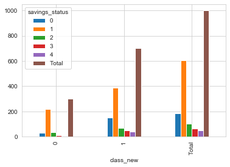

```python
t = pd.crosstab(dm.class_new, dm.savings_status, margins=True, margins_name="Total").plot(kind='bar')
```

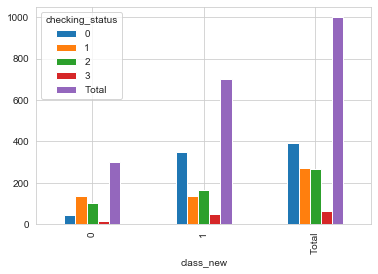

```python
l = pd.crosstab(dm.class_new, dm.checking_status, margins=True, margins_name="Total").plot(kind='bar')
```

```python
from scipy.stats import chi2_contingency
stat,p,dof,expected =chi2_contingency(dm)
p
```

```
0.0
```

### since our p-values <alpha we reject the null so, the features have a significant relationship.

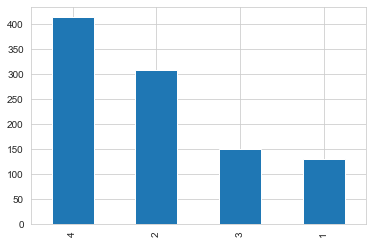

```python
# residnecy frequence
dm.copy()
dm['residence_since'].value_counts().plot('bar')
```

```python
dm.columns
```

```
Index(['checking_status', 'duration', 'credit_amount', 'savings_status',
       'employment', 'installment_commitment', 'residence_since', 'age',
       'existing_credits', 'num_dependents', 'parties_co applicant',
       'parties_guarantor', 'parties_none', 'credit_h_all paid',
       'credit_h_critical/other existing credit',
       'credit_h_delayed previously', 'credit_h_existing paid',
       'credit_h_no credits/all paid', 'purpose_business',
       'purpose_domestic appliance', 'purpose_education',
       'purpose_furniture/equipment', 'purpose_new car', 'purpose_other',
       'purpose_radio/tv', 'purpose_repairs', 'purpose_retraining',
       'purpose_used car', 'status_female div/dep/mar', 'status_male div/sep',
       'status_male mar/wid', 'status_male single', 'class_new',
       'foreign_worker_new', 'own_telephone_new',
       'job_status_high qualif/self emp/mgmt', 'job_status_skilled',
       'job_status_unemp/unskilled non res', 'job_status_unskilled resident',
       'housing_status_for free', 'housing_status_own', 'housing_status_rent',
       'payment_plans_status_bank', 'payment_plans_status_none',
       'payment_plans_status_stores', 'property_magnitude_status_car',
       'property_magnitude_status_life insurance',
       'property_magnitude_status_no known property',
       'property_magnitude_status_real estate'],
      dtype='object')
```

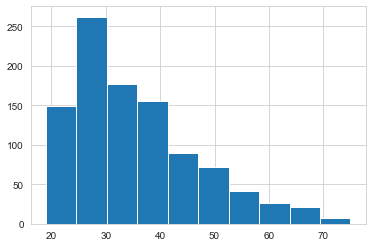

```python
# Frequency of age
dm['age'].hist()
```